# Risk Factor Analysis

## Outcome Variable

**Outcome Variable:** ever_stunted

## Predictor Variables

**Intervention Variable:** hfoodsec

**Adjustment Set:**

unadjusted

## Stratifying Variables

The analysis was stratified on these variable(s):

- agecat
- studyid
- country

## Data Summary

| agecat | studyid | country | A | n | nA | nAY0 | nAY1 |
| --- | --- | --- | --- | --- | --- | --- | --- |
| 3 months | ki0047075b-MAL-ED | BANGLADESH | Food Secure | 194 | 161 | 118 | 43 |
| 3 months | ki0047075b-MAL-ED | BANGLADESH | Mildly Food Insecure | 194 | 4 | 3 | 1 |
| 3 months | ki0047075b-MAL-ED | BANGLADESH | Moderately Food Insecure | 194 | 23 | 20 | 3 |
| 3 months | ki0047075b-MAL-ED | BANGLADESH | Severely Food Insecure | 194 | 6 | 3 | 3 |
| 3 months | ki0047075b-MAL-ED | BRAZIL | Food Secure | 129 | 3 | 3 | 0 |
| 3 months | ki0047075b-MAL-ED | BRAZIL | Mildly Food Insecure | 129 | 11 | 8 | 3 |
| 3 months | ki0047075b-MAL-ED | BRAZIL | Moderately Food Insecure | 129 | 67 | 55 | 12 |
| 3 months | ki0047075b-MAL-ED | BRAZIL | Severely Food Insecure | 129 | 48 | 45 | 3 |
| 3 months | ki0047075b-MAL-ED | INDIA | Food Secure | 212 | 190 | 138 | 52 |
| 3 months | ki0047075b-MAL-ED | INDIA | Mildly Food Insecure | 212 | 5 | 5 | 0 |
| 3 months | ki0047075b-MAL-ED | INDIA | Moderately Food Insecure | 212 | 4 | 3 | 1 |
| 3 months | ki0047075b-MAL-ED | INDIA | Severely Food Insecure | 212 | 13 | 11 | 2 |
| 3 months | ki0047075b-MAL-ED | NEPAL | Food Secure | 128 | 94 | 82 | 12 |
| 3 months | ki0047075b-MAL-ED | NEPAL | Mildly Food Insecure | 128 | 15 | 12 | 3 |
| 3 months | ki0047075b-MAL-ED | NEPAL | Moderately Food Insecure | 128 | 16 | 11 | 5 |
| 3 months | ki0047075b-MAL-ED | NEPAL | Severely Food Insecure | 128 | 3 | 3 | 0 |
| 3 months | ki0047075b-MAL-ED | PERU | Food Secure | 113 | 27 | 15 | 12 |
| 3 months | ki0047075b-MAL-ED | PERU | Mildly Food Insecure | 113 | 29 | 21 | 8 |
| 3 months | ki0047075b-MAL-ED | PERU | Moderately Food Insecure | 113 | 28 | 22 | 6 |
| 3 months | ki0047075b-MAL-ED | PERU | Severely Food Insecure | 113 | 29 | 16 | 13 |
| 3 months | ki0047075b-MAL-ED | SOUTH AFRICA | Food Secure | 233 | 132 | 96 | 36 |
| 3 months | ki0047075b-MAL-ED | SOUTH AFRICA | Mildly Food Insecure | 233 | 19 | 17 | 2 |
| 3 months | ki0047075b-MAL-ED | SOUTH AFRICA | Moderately Food Insecure | 233 | 76 | 54 | 22 |
| 3 months | ki0047075b-MAL-ED | SOUTH AFRICA | Severely Food Insecure | 233 | 6 | 5 | 1 |
| 3 months | ki1017093-NIH-Birth | BANGLADESH | Food Secure | 629 | 95 | 78 | 17 |
| 3 months | ki1017093-NIH-Birth | BANGLADESH | Mildly Food Insecure | 629 | 492 | 382 | 110 |
| 3 months | ki1017093-NIH-Birth | BANGLADESH | Moderately Food Insecure | 629 | 36 | 25 | 11 |
| 3 months | ki1017093-NIH-Birth | BANGLADESH | Severely Food Insecure | 629 | 6 | 4 | 2 |
| 3 months | ki1017093c-NIH-Crypto | BANGLADESH | Food Secure | 758 | 453 | 388 | 65 |
| 3 months | ki1017093c-NIH-Crypto | BANGLADESH | Mildly Food Insecure | 758 | 219 | 180 | 39 |

[output cut: 150 more lines]

The following strata were considered:

- agecat: 12 months, studyid: ki0047075b-MAL-ED, country: BANGLADESH
- agecat: 12 months, studyid: ki0047075b-MAL-ED, country: BRAZIL
- agecat: 12 months, studyid: ki0047075b-MAL-ED, country: INDIA
- agecat: 12 months, studyid: ki0047075b-MAL-ED, country: NEPAL
- agecat: 12 months, studyid: ki0047075b-MAL-ED, country: PERU
- agecat: 12 months, studyid: ki0047075b-MAL-ED, country: SOUTH AFRICA
- agecat: 12 months, studyid: ki1017093-NIH-Birth, country: BANGLADESH
- agecat: 12 months, studyid: ki1017093c-NIH-Crypto, country: BANGLADESH
- agecat: 12 months, studyid: ki1113344-GMS-Nepal, country: NEPAL
- agecat: 18 months, studyid: ki0047075b-MAL-ED, country: BANGLADESH
- agecat: 18 months, studyid: ki0047075b-MAL-ED, country: BRAZIL
- agecat: 18 months, studyid: ki0047075b-MAL-ED, country: INDIA
- agecat: 18 months, studyid: ki0047075b-MAL-ED, country: NEPAL
- agecat: 18 months, studyid: ki0047075b-MAL-ED, country: PERU
- agecat: 18 months, studyid: ki0047075b-MAL-ED, country: SOUTH AFRICA
- agecat: 18 months, studyid: ki1017093-NIH-Birth, country: BANGLADESH
- agecat: 18 months, studyid: ki1017093c-NIH-Crypto, country: BANGLADESH
- agecat: 18 months, studyid: ki1113344-GMS-Nepal, country: NEPAL
- agecat: 24 months, studyid: ki0047075b-MAL-ED, country: BANGLADESH
- agecat: 24 months, studyid: ki0047075b-MAL-ED, country: BRAZIL
- agecat: 24 months, studyid: ki0047075b-MAL-ED, country: INDIA
- agecat: 24 months, studyid: ki0047075b-MAL-ED, country: NEPAL
- agecat: 24 months, studyid: ki0047075b-MAL-ED, country: PERU
- agecat: 24 months, studyid: ki0047075b-MAL-ED, country: SOUTH AFRICA
- agecat: 24 months, studyid: ki1017093-NIH-Birth, country: BANGLADESH
- agecat: 24 months, studyid: ki1017093c-NIH-Crypto, country: BANGLADESH
- agecat: 24 months, studyid: ki1113344-GMS-Nepal, country: NEPAL
- agecat: 3 months, studyid: ki0047075b-MAL-ED, country: BANGLADESH
- agecat: 3 months, studyid: ki0047075b-MAL-ED, country: BRAZIL
- agecat: 3 months, studyid: ki0047075b-MAL-ED, country: INDIA
- agecat: 3 months, studyid: ki0047075b-MAL-ED, country: NEPAL
- agecat: 3 months, studyid: ki0047075b-MAL-ED, country: PERU
- agecat: 3 months, studyid: ki0047075b-MAL-ED, country: SOUTH AFRICA
- agecat: 3 months, studyid: ki1017093-NIH-Birth, country: BANGLADESH
- agecat: 3 months, studyid: ki1017093c-NIH-Crypto, country: BANGLADESH
- agecat: 3 months, studyid: ki1113344-GMS-Nepal, country: NEPAL
- agecat: 6 months, studyid: ki0047075b-MAL-ED, country: BANGLADESH
- agecat: 6 months, studyid: ki0047075b-MAL-ED, country: BRAZIL
- agecat: 6 months, studyid: ki0047075b-MAL-ED, country: INDIA
- agecat: 6 months, studyid: ki0047075b-MAL-ED, country: NEPAL
- agecat: 6 months, studyid: ki0047075b-MAL-ED, country: PERU
- agecat: 6 months, studyid: ki0047075b-MAL-ED, country: SOUTH AFRICA
- agecat: 6 months, studyid: ki1017093-NIH-Birth, country: BANGLADESH
- agecat: 6 months, studyid: ki1017093c-NIH-Crypto, country: BANGLADESH
- agecat: 6 months, studyid: ki1113344-GMS-Nepal, country: NEPAL

### Dropped Strata

Some strata were dropped due to rare outcomes:

- agecat: 3 months, studyid: ki0047075b-MAL-ED, country: BANGLADESH
- agecat: 3 months, studyid: ki0047075b-MAL-ED, country: BRAZIL
- agecat: 3 months, studyid: ki0047075b-MAL-ED, country: INDIA
- agecat: 3 months, studyid: ki0047075b-MAL-ED, country: NEPAL
- agecat: 3 months, studyid: ki0047075b-MAL-ED, country: SOUTH AFRICA
- agecat: 3 months, studyid: ki1017093-NIH-Birth, country: BANGLADESH
- agecat: 6 months, studyid: ki0047075b-MAL-ED, country: BANGLADESH
- agecat: 6 months, studyid: ki0047075b-MAL-ED, country: BRAZIL
- agecat: 6 months, studyid: ki0047075b-MAL-ED, country: INDIA
- agecat: 6 months, studyid: ki0047075b-MAL-ED, country: NEPAL
- agecat: 6 months, studyid: ki0047075b-MAL-ED, country: SOUTH AFRICA
- agecat: 6 months, studyid: ki1017093-NIH-Birth, country: BANGLADESH
- agecat: 12 months, studyid: ki0047075b-MAL-ED, country: BANGLADESH
- agecat: 12 months, studyid: ki0047075b-MAL-ED, country: BRAZIL
- agecat: 12 months, studyid: ki0047075b-MAL-ED, country: INDIA
- agecat: 12 months, studyid: ki0047075b-MAL-ED, country: NEPAL
- agecat: 12 months, studyid: ki0047075b-MAL-ED, country: SOUTH AFRICA
- agecat: 12 months, studyid: ki1017093-NIH-Birth, country: BANGLADESH
- agecat: 18 months, studyid: ki0047075b-MAL-ED, country: BANGLADESH
- agecat: 18 months, studyid: ki0047075b-MAL-ED, country: BRAZIL
- agecat: 18 months, studyid: ki0047075b-MAL-ED, country: INDIA
- agecat: 18 months, studyid: ki0047075b-MAL-ED, country: NEPAL
- agecat: 18 months, studyid: ki0047075b-MAL-ED, country: SOUTH AFRICA
- agecat: 18 months, studyid: ki1017093-NIH-Birth, country: BANGLADESH
- agecat: 24 months, studyid: ki0047075b-MAL-ED, country: BANGLADESH
- agecat: 24 months, studyid: ki0047075b-MAL-ED, country: BRAZIL
- agecat: 24 months, studyid: ki0047075b-MAL-ED, country: INDIA
- agecat: 24 months, studyid: ki0047075b-MAL-ED, country: NEPAL
- agecat: 24 months, studyid: ki0047075b-MAL-ED, country: SOUTH AFRICA
- agecat: 24 months, studyid: ki1017093-NIH-Birth, country: BANGLADESH

## Methods Detail

We’re interested in the causal parameters $E[Y_a]$ for all values of $a \in \mathcal{A}$. These parameters represent the mean outcome if, possibly contrary to fact, we intervened to set all units to have $A=a$. Under the randomization and positivity assumptions, these are identified by the statistical parameters $\psi_a=E_W[E_{Y|A,W}(Y|A=a,W)]$. In addition, we’re interested in the mean of $Y$, $E[Y]$ under no intervention (the observed mean). We will estimate these parameters by using SuperLearner to fit the relevant likelihood factors – $E_{Y|A,W}(Y|A=a,W)$ and $p(A=a|W)$, and then updating our likelihood fit using a joint TMLE.

For unadjusted analyses ($W=\{\}$), initial likelihoods were estimated using Lrnr_glm to estimate the simple $E(Y|A)$ and Lrnr_mean to estimate $p(A)$. For adjusted analyses, a small library containing Lrnr_glmnet, Lrnr_xgboost, and Lrnr_mean was used.

Having estimated these parameters, we will then use the delta method to estimate relative risks and attributable risks relative to a prespecified baseline level of $A$.

# Results Detail

## Results Plots

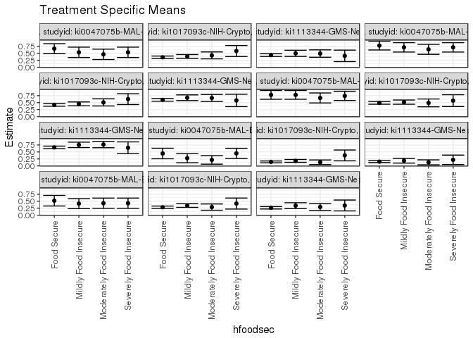

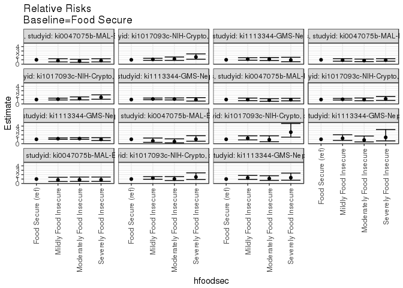

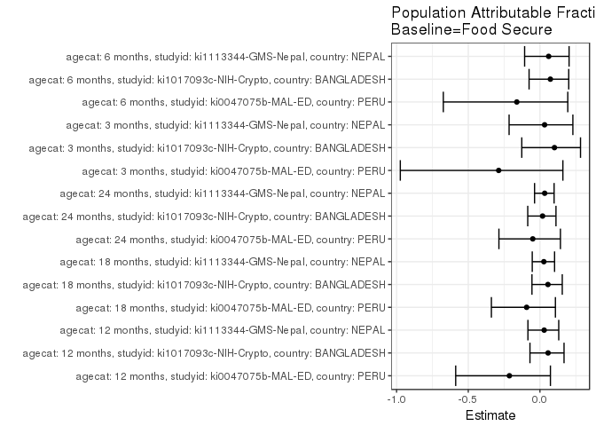

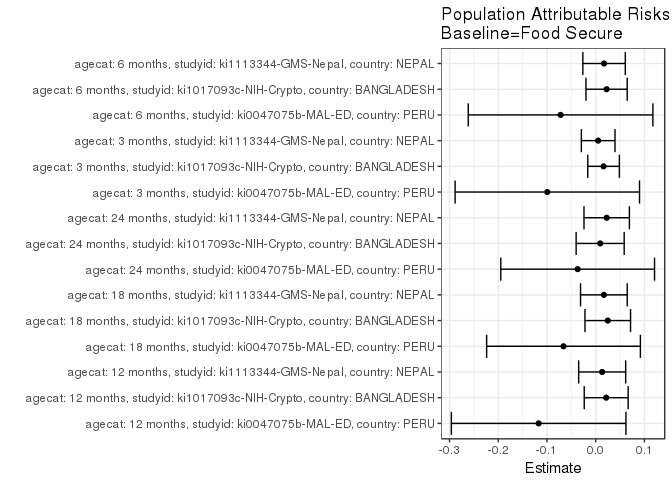

## Results Table

### Parameter: TSM

| agecat | studyid | country | intervention_level | baseline_level | estimate | ci_lower | ci_upper |
| --- | --- | --- | --- | --- | --- | --- | --- |
| 3 months | ki0047075b-MAL-ED | PERU | Food Secure | NA | 0.4444444 | 0.2561797 | 0.6327091 |
| 3 months | ki0047075b-MAL-ED | PERU | Mildly Food Insecure | NA | 0.2758621 | 0.1124681 | 0.4392560 |
| 3 months | ki0047075b-MAL-ED | PERU | Moderately Food Insecure | NA | 0.2142857 | 0.0616247 | 0.3669468 |
| 3 months | ki0047075b-MAL-ED | PERU | Severely Food Insecure | NA | 0.4482759 | 0.2664679 | 0.6300839 |
| 3 months | ki1017093c-NIH-Crypto | BANGLADESH | Food Secure | NA | 0.1434879 | 0.1111836 | 0.1757921 |
| 3 months | ki1017093c-NIH-Crypto | BANGLADESH | Mildly Food Insecure | NA | 0.1780822 | 0.1273788 | 0.2287856 |
| 3 months | ki1017093c-NIH-Crypto | BANGLADESH | Moderately Food Insecure | NA | 0.1290323 | 0.0455318 | 0.2125328 |
| 3 months | ki1017093c-NIH-Crypto | BANGLADESH | Severely Food Insecure | NA | 0.3750000 | 0.1811862 | 0.5688138 |
| 3 months | ki1113344-GMS-Nepal | NEPAL | Food Secure | NA | 0.1514423 | 0.1169642 | 0.1859204 |
| 3 months | ki1113344-GMS-Nepal | NEPAL | Mildly Food Insecure | NA | 0.1851852 | 0.1005178 | 0.2698526 |
| 3 months | ki1113344-GMS-Nepal | NEPAL | Moderately Food Insecure | NA | 0.1272727 | 0.0391168 | 0.2154287 |
| 3 months | ki1113344-GMS-Nepal | NEPAL | Severely Food Insecure | NA | 0.2173913 | 0.0486756 | 0.3861070 |
| 6 months | ki0047075b-MAL-ED | PERU | Food Secure | NA | 0.5185185 | 0.3292032 | 0.7078338 |
| 6 months | ki0047075b-MAL-ED | PERU | Mildly Food Insecure | NA | 0.4137931 | 0.2337346 | 0.5938516 |
| 6 months | ki0047075b-MAL-ED | PERU | Moderately Food Insecure | NA | 0.4285714 | 0.2444479 | 0.6126949 |
| 6 months | ki0047075b-MAL-ED | PERU | Severely Food Insecure | NA | 0.4285714 | 0.2444479 | 0.6126949 |
| 6 months | ki1017093c-NIH-Crypto | BANGLADESH | Food Secure | NA | 0.2847380 | 0.2424939 | 0.3269822 |
| 6 months | ki1017093c-NIH-Crypto | BANGLADESH | Mildly Food Insecure | NA | 0.3459716 | 0.2817441 | 0.4101990 |
| 6 months | ki1017093c-NIH-Crypto | BANGLADESH | Moderately Food Insecure | NA | 0.2903226 | 0.1772601 | 0.4033850 |
| 6 months | ki1017093c-NIH-Crypto | BANGLADESH | Severely Food Insecure | NA | 0.4166667 | 0.2192924 | 0.6140409 |
| 6 months | ki1113344-GMS-Nepal | NEPAL | Food Secure | NA | 0.2651515 | 0.2216362 | 0.3086669 |
| 6 months | ki1113344-GMS-Nepal | NEPAL | Mildly Food Insecure | NA | 0.3417722 | 0.2370866 | 0.4464577 |
| 6 months | ki1113344-GMS-Nepal | NEPAL | Moderately Food Insecure | NA | 0.2941176 | 0.1689519 | 0.4192834 |
| 6 months | ki1113344-GMS-Nepal | NEPAL | Severely Food Insecure | NA | 0.3478261 | 0.1530019 | 0.5426503 |
| 12 months | ki0047075b-MAL-ED | PERU | Food Secure | NA | 0.6666667 | 0.4880487 | 0.8452846 |
| 12 months | ki0047075b-MAL-ED | PERU | Mildly Food Insecure | NA | 0.5357143 | 0.3501504 | 0.7212782 |
| 12 months | ki0047075b-MAL-ED | PERU | Moderately Food Insecure | NA | 0.4642857 | 0.2787218 | 0.6498496 |
| 12 months | ki0047075b-MAL-ED | PERU | Severely Food Insecure | NA | 0.5357143 | 0.3501504 | 0.7212782 |
| 12 months | ki1017093c-NIH-Crypto | BANGLADESH | Food Secure | NA | 0.3584475 | 0.3135070 | 0.4033880 |
| 12 months | ki1017093c-NIH-Crypto | BANGLADESH | Mildly Food Insecure | NA | 0.3883495 | 0.3217493 | 0.4549497 |
| 12 months | ki1017093c-NIH-Crypto | BANGLADESH | Moderately Food Insecure | NA | 0.4262295 | 0.3020437 | 0.5504154 |
| 12 months | ki1017093c-NIH-Crypto | BANGLADESH | Severely Food Insecure | NA | 0.5833333 | 0.3859578 | 0.7807089 |
| 12 months | ki1113344-GMS-Nepal | NEPAL | Food Secure | NA | 0.4362745 | 0.3881112 | 0.4844378 |
| 12 months | ki1113344-GMS-Nepal | NEPAL | Mildly Food Insecure | NA | 0.5000000 | 0.3903376 | 0.6096624 |
| 12 months | ki1113344-GMS-Nepal | NEPAL | Moderately Food Insecure | NA | 0.4909091 | 0.3586731 | 0.6231451 |
| 12 months | ki1113344-GMS-Nepal | NEPAL | Severely Food Insecure | NA | 0.4090909 | 0.2034585 | 0.6147234 |
| 18 months | ki0047075b-MAL-ED | PERU | Food Secure | NA | 0.7777778 | 0.6202516 | 0.9353040 |
| 18 months | ki0047075b-MAL-ED | PERU | Mildly Food Insecure | NA | 0.7142857 | 0.5461979 | 0.8823735 |
| 18 months | ki0047075b-MAL-ED | PERU | Moderately Food Insecure | NA | 0.6428571 | 0.4645731 | 0.8211412 |
| 18 months | ki0047075b-MAL-ED | PERU | Severely Food Insecure | NA | 0.7142857 | 0.5461979 | 0.8823735 |
| 18 months | ki1017093c-NIH-Crypto | BANGLADESH | Food Secure | NA | 0.4186047 | 0.3719435 | 0.4652658 |
| 18 months | ki1017093c-NIH-Crypto | BANGLADESH | Mildly Food Insecure | NA | 0.4554455 | 0.3867205 | 0.5241706 |
| 18 months | ki1017093c-NIH-Crypto | BANGLADESH | Moderately Food Insecure | NA | 0.5084746 | 0.3808208 | 0.6361283 |
| 18 months | ki1017093c-NIH-Crypto | BANGLADESH | Severely Food Insecure | NA | 0.6250000 | 0.4311785 | 0.8188215 |
| 18 months | ki1113344-GMS-Nepal | NEPAL | Food Secure | NA | 0.5990099 | 0.5511765 | 0.6468433 |
| 18 months | ki1113344-GMS-Nepal | NEPAL | Mildly Food Insecure | NA | 0.6750000 | 0.5722725 | 0.7777275 |
| 18 months | ki1113344-GMS-Nepal | NEPAL | Moderately Food Insecure | NA | 0.6666667 | 0.5408219 | 0.7925114 |
| 18 months | ki1113344-GMS-Nepal | NEPAL | Severely Food Insecure | NA | 0.5789474 | 0.3567447 | 0.8011500 |
| 24 months | ki0047075b-MAL-ED | PERU | Food Secure | NA | 0.7777778 | 0.6202317 | 0.9353239 |
| 24 months | ki0047075b-MAL-ED | PERU | Mildly Food Insecure | NA | 0.7777778 | 0.6202317 | 0.9353239 |
| 24 months | ki0047075b-MAL-ED | PERU | Moderately Food Insecure | NA | 0.6666667 | 0.4880262 | 0.8453072 |
| 24 months | ki0047075b-MAL-ED | PERU | Severely Food Insecure | NA | 0.7407407 | 0.5746726 | 0.9068089 |
| 24 months | ki1017093c-NIH-Crypto | BANGLADESH | Food Secure | NA | 0.4924242 | 0.4431451 | 0.5417034 |
| 24 months | ki1017093c-NIH-Crypto | BANGLADESH | Mildly Food Insecure | NA | 0.5178571 | 0.4422385 | 0.5934758 |
| 24 months | ki1017093c-NIH-Crypto | BANGLADESH | Moderately Food Insecure | NA | 0.4897959 | 0.3497171 | 0.6298747 |
| 24 months | ki1017093c-NIH-Crypto | BANGLADESH | Severely Food Insecure | NA | 0.5714286 | 0.3596052 | 0.7832519 |
| 24 months | ki1113344-GMS-Nepal | NEPAL | Food Secure | NA | 0.6616541 | 0.6151863 | 0.7081219 |
| 24 months | ki1113344-GMS-Nepal | NEPAL | Mildly Food Insecure | NA | 0.7532468 | 0.6568645 | 0.8496290 |
| 24 months | ki1113344-GMS-Nepal | NEPAL | Moderately Food Insecure | NA | 0.7636364 | 0.6512549 | 0.8760179 |
| 24 months | ki1113344-GMS-Nepal | NEPAL | Severely Food Insecure | NA | 0.6500000 | 0.4407727 | 0.8592273 |

### Parameter: E(Y)

| agecat | studyid | country | intervention_level | baseline_level | estimate | ci_lower | ci_upper |
| --- | --- | --- | --- | --- | --- | --- | --- |
| 3 months | ki0047075b-MAL-ED | PERU | NA | NA | 0.3451327 | 0.3261007 | 0.3641647 |
| 3 months | ki1017093c-NIH-Crypto | BANGLADESH | NA | NA | 0.1596306 | 0.1566089 | 0.1626523 |
| 3 months | ki1113344-GMS-Nepal | NEPAL | NA | NA | 0.1565217 | 0.1549600 | 0.1580835 |
| 6 months | ki0047075b-MAL-ED | PERU | NA | NA | 0.4464286 | 0.4387853 | 0.4540719 |
| 6 months | ki1017093c-NIH-Crypto | BANGLADESH | NA | NA | 0.3070652 | 0.3046172 | 0.3095132 |
| 6 months | ki1113344-GMS-Nepal | NEPAL | NA | NA | 0.2823315 | 0.2798004 | 0.2848626 |
| 12 months | ki0047075b-MAL-ED | PERU | NA | NA | 0.5495495 | 0.5359874 | 0.5631117 |
| 12 months | ki1017093c-NIH-Crypto | BANGLADESH | NA | NA | 0.3799726 | 0.3768577 | 0.3830875 |
| 12 months | ki1113344-GMS-Nepal | NEPAL | NA | NA | 0.4495575 | 0.4473463 | 0.4517688 |
| 18 months | ki0047075b-MAL-ED | PERU | NA | NA | 0.7117117 | 0.7028259 | 0.7205975 |
| 18 months | ki1017093c-NIH-Crypto | BANGLADESH | NA | NA | 0.4433566 | 0.4401872 | 0.4465261 |
| 18 months | ki1113344-GMS-Nepal | NEPAL | NA | NA | 0.6157989 | 0.6131638 | 0.6184340 |
| 24 months | ki0047075b-MAL-ED | PERU | NA | NA | 0.7407407 | 0.7321459 | 0.7493356 |
| 24 months | ki1017093c-NIH-Crypto | BANGLADESH | NA | NA | 0.5015773 | 0.5002395 | 0.5029151 |
| 24 months | ki1113344-GMS-Nepal | NEPAL | NA | NA | 0.6842105 | 0.6807580 | 0.6876631 |

### Parameter: RR

| agecat | studyid | country | intervention_level | baseline_level | estimate | ci_lower | ci_upper |
| --- | --- | --- | --- | --- | --- | --- | --- |
| 3 months | ki0047075b-MAL-ED | PERU | Food Secure | Food Secure | 1.0000000 | 1.0000000 | 1.000000 |
| 3 months | ki0047075b-MAL-ED | PERU | Mildly Food Insecure | Food Secure | 0.6206897 | 0.2996588 | 1.285648 |
| 3 months | ki0047075b-MAL-ED | PERU | Moderately Food Insecure | Food Secure | 0.4821429 | 0.2104824 | 1.104424 |
| 3 months | ki0047075b-MAL-ED | PERU | Severely Food Insecure | Food Secure | 1.0086207 | 0.5610953 | 1.813089 |
| 3 months | ki1017093c-NIH-Crypto | BANGLADESH | Food Secure | Food Secure | 1.0000000 | 1.0000000 | 1.000000 |
| 3 months | ki1017093c-NIH-Crypto | BANGLADESH | Mildly Food Insecure | Food Secure | 1.2410959 | 0.8633107 | 1.784200 |
| 3 months | ki1017093c-NIH-Crypto | BANGLADESH | Moderately Food Insecure | Food Secure | 0.8992556 | 0.4532275 | 1.784226 |
| 3 months | ki1017093c-NIH-Crypto | BANGLADESH | Severely Food Insecure | Food Secure | 2.6134615 | 1.4872552 | 4.592474 |
| 3 months | ki1113344-GMS-Nepal | NEPAL | Food Secure | Food Secure | 1.0000000 | 1.0000000 | 1.000000 |
| 3 months | ki1113344-GMS-Nepal | NEPAL | Mildly Food Insecure | Food Secure | 1.2228101 | 0.7337407 | 2.037865 |
| 3 months | ki1113344-GMS-Nepal | NEPAL | Moderately Food Insecure | Food Secure | 0.8404040 | 0.4053590 | 1.742354 |
| 3 months | ki1113344-GMS-Nepal | NEPAL | Severely Food Insecure | Food Secure | 1.4354727 | 0.6393510 | 3.222927 |
| 6 months | ki0047075b-MAL-ED | PERU | Food Secure | Food Secure | 1.0000000 | 1.0000000 | 1.000000 |
| 6 months | ki0047075b-MAL-ED | PERU | Mildly Food Insecure | Food Secure | 0.7980296 | 0.4521984 | 1.408345 |
| 6 months | ki0047075b-MAL-ED | PERU | Moderately Food Insecure | Food Secure | 0.8265306 | 0.4703278 | 1.452504 |
| 6 months | ki0047075b-MAL-ED | PERU | Severely Food Insecure | Food Secure | 0.8265306 | 0.4703278 | 1.452504 |
| 6 months | ki1017093c-NIH-Crypto | BANGLADESH | Food Secure | Food Secure | 1.0000000 | 1.0000000 | 1.000000 |
| 6 months | ki1017093c-NIH-Crypto | BANGLADESH | Mildly Food Insecure | Food Secure | 1.2150521 | 0.9580483 | 1.540999 |
| 6 months | ki1017093c-NIH-Crypto | BANGLADESH | Moderately Food Insecure | Food Secure | 1.0196129 | 0.6721207 | 1.546761 |
| 6 months | ki1017093c-NIH-Crypto | BANGLADESH | Severely Food Insecure | Food Secure | 1.4633333 | 0.8907682 | 2.403930 |
| 6 months | ki1113344-GMS-Nepal | NEPAL | Food Secure | Food Secure | 1.0000000 | 1.0000000 | 1.000000 |
| 6 months | ki1113344-GMS-Nepal | NEPAL | Mildly Food Insecure | Food Secure | 1.2889693 | 0.9105968 | 1.824564 |
| 6 months | ki1113344-GMS-Nepal | NEPAL | Moderately Food Insecure | Food Secure | 1.1092437 | 0.7029753 | 1.750306 |
| 6 months | ki1113344-GMS-Nepal | NEPAL | Severely Food Insecure | Food Secure | 1.3118012 | 0.7317867 | 2.351536 |
| 12 months | ki0047075b-MAL-ED | PERU | Food Secure | Food Secure | 1.0000000 | 1.0000000 | 1.000000 |
| 12 months | ki0047075b-MAL-ED | PERU | Mildly Food Insecure | Food Secure | 0.8035714 | 0.5186103 | 1.245110 |
| 12 months | ki0047075b-MAL-ED | PERU | Moderately Food Insecure | Food Secure | 0.6964286 | 0.4304340 | 1.126799 |
| 12 months | ki0047075b-MAL-ED | PERU | Severely Food Insecure | Food Secure | 0.8035714 | 0.5186103 | 1.245110 |
| 12 months | ki1017093c-NIH-Crypto | BANGLADESH | Food Secure | Food Secure | 1.0000000 | 1.0000000 | 1.000000 |
| 12 months | ki1017093c-NIH-Crypto | BANGLADESH | Mildly Food Insecure | Food Secure | 1.0834209 | 0.8760659 | 1.339855 |
| 12 months | ki1017093c-NIH-Crypto | BANGLADESH | Moderately Food Insecure | Food Secure | 1.1890989 | 0.8658933 | 1.632945 |
| 12 months | ki1017093c-NIH-Crypto | BANGLADESH | Severely Food Insecure | Food Secure | 1.6273885 | 1.1344376 | 2.334543 |
| 12 months | ki1113344-GMS-Nepal | NEPAL | Food Secure | Food Secure | 1.0000000 | 1.0000000 | 1.000000 |
| 12 months | ki1113344-GMS-Nepal | NEPAL | Mildly Food Insecure | Food Secure | 1.1460674 | 0.8965462 | 1.465034 |
| 12 months | ki1113344-GMS-Nepal | NEPAL | Moderately Food Insecure | Food Secure | 1.1252298 | 0.8410310 | 1.505464 |
| 12 months | ki1113344-GMS-Nepal | NEPAL | Severely Food Insecure | Food Secure | 0.9376915 | 0.5604745 | 1.568788 |
| 18 months | ki0047075b-MAL-ED | PERU | Food Secure | Food Secure | 1.0000000 | 1.0000000 | 1.000000 |
| 18 months | ki0047075b-MAL-ED | PERU | Mildly Food Insecure | Food Secure | 0.9183673 | 0.6732516 | 1.252724 |
| 18 months | ki0047075b-MAL-ED | PERU | Moderately Food Insecure | Food Secure | 0.8265306 | 0.5862957 | 1.165202 |
| 18 months | ki0047075b-MAL-ED | PERU | Severely Food Insecure | Food Secure | 0.9183673 | 0.6732516 | 1.252724 |
| 18 months | ki1017093c-NIH-Crypto | BANGLADESH | Food Secure | Food Secure | 1.0000000 | 1.0000000 | 1.000000 |
| 18 months | ki1017093c-NIH-Crypto | BANGLADESH | Mildly Food Insecure | Food Secure | 1.0880088 | 0.9018980 | 1.312524 |
| 18 months | ki1017093c-NIH-Crypto | BANGLADESH | Moderately Food Insecure | Food Secure | 1.2146893 | 0.9229337 | 1.598674 |
| 18 months | ki1017093c-NIH-Crypto | BANGLADESH | Severely Food Insecure | Food Secure | 1.4930556 | 1.0738877 | 2.075836 |
| 18 months | ki1113344-GMS-Nepal | NEPAL | Food Secure | Food Secure | 1.0000000 | 1.0000000 | 1.000000 |
| 18 months | ki1113344-GMS-Nepal | NEPAL | Mildly Food Insecure | Food Secure | 1.1268595 | 0.9489187 | 1.338168 |
| 18 months | ki1113344-GMS-Nepal | NEPAL | Moderately Food Insecure | Food Secure | 1.1129477 | 0.9066936 | 1.366120 |
| 18 months | ki1113344-GMS-Nepal | NEPAL | Severely Food Insecure | Food Secure | 0.9665072 | 0.6530574 | 1.430404 |
| 24 months | ki0047075b-MAL-ED | PERU | Food Secure | Food Secure | 1.0000000 | 1.0000000 | 1.000000 |
| 24 months | ki0047075b-MAL-ED | PERU | Mildly Food Insecure | Food Secure | 1.0000000 | 0.7509155 | 1.331708 |
| 24 months | ki0047075b-MAL-ED | PERU | Moderately Food Insecure | Food Secure | 0.8571429 | 0.6125913 | 1.199321 |
| 24 months | ki0047075b-MAL-ED | PERU | Severely Food Insecure | Food Secure | 0.9523810 | 0.7040285 | 1.288342 |
| 24 months | ki1017093c-NIH-Crypto | BANGLADESH | Food Secure | Food Secure | 1.0000000 | 1.0000000 | 1.000000 |
| 24 months | ki1017093c-NIH-Crypto | BANGLADESH | Mildly Food Insecure | Food Secure | 1.0516484 | 0.8810287 | 1.255310 |
| 24 months | ki1017093c-NIH-Crypto | BANGLADESH | Moderately Food Insecure | Food Secure | 0.9946625 | 0.7346585 | 1.346685 |
| 24 months | ki1017093c-NIH-Crypto | BANGLADESH | Severely Food Insecure | Food Secure | 1.1604396 | 0.7904421 | 1.703629 |
| 24 months | ki1113344-GMS-Nepal | NEPAL | Food Secure | Food Secure | 1.0000000 | 1.0000000 | 1.000000 |
| 24 months | ki1113344-GMS-Nepal | NEPAL | Mildly Food Insecure | Food Secure | 1.1384298 | 0.9838202 | 1.317336 |
| 24 months | ki1113344-GMS-Nepal | NEPAL | Moderately Food Insecure | Food Secure | 1.1541322 | 0.9804771 | 1.358544 |
| 24 months | ki1113344-GMS-Nepal | NEPAL | Severely Food Insecure | Food Secure | 0.9823864 | 0.7066421 | 1.365731 |

### Parameter: PAR

| agecat | studyid | country | intervention_level | baseline_level | estimate | ci_lower | ci_upper |
| --- | --- | --- | --- | --- | --- | --- | --- |
| 3 months | ki0047075b-MAL-ED | PERU | Food Secure | NA | -0.0993117 | -0.2885359 | 0.0899125 |
| 3 months | ki1017093c-NIH-Crypto | BANGLADESH | Food Secure | NA | 0.0161427 | -0.0163025 | 0.0485880 |
| 3 months | ki1113344-GMS-Nepal | NEPAL | Food Secure | NA | 0.0050794 | -0.0294341 | 0.0395929 |
| 6 months | ki0047075b-MAL-ED | PERU | Food Secure | NA | -0.0720899 | -0.2615595 | 0.1173796 |
| 6 months | ki1017093c-NIH-Crypto | BANGLADESH | Food Secure | NA | 0.0223272 | -0.0199878 | 0.0646422 |
| 6 months | ki1113344-GMS-Nepal | NEPAL | Food Secure | NA | 0.0171800 | -0.0264089 | 0.0607689 |
| 12 months | ki0047075b-MAL-ED | PERU | Food Secure | NA | -0.1171171 | -0.2962492 | 0.0620150 |
| 12 months | ki1017093c-NIH-Crypto | BANGLADESH | Food Secure | NA | 0.0215251 | -0.0235233 | 0.0665734 |
| 12 months | ki1113344-GMS-Nepal | NEPAL | Food Secure | NA | 0.0132830 | -0.0349310 | 0.0614971 |
| 18 months | ki0047075b-MAL-ED | PERU | Food Secure | NA | -0.0660661 | -0.2238427 | 0.0917106 |
| 18 months | ki1017093c-NIH-Crypto | BANGLADESH | Food Secure | NA | 0.0247520 | -0.0220167 | 0.0715207 |
| 18 months | ki1113344-GMS-Nepal | NEPAL | Food Secure | NA | 0.0167890 | -0.0311169 | 0.0646950 |
| 24 months | ki0047075b-MAL-ED | PERU | Food Secure | NA | -0.0370370 | -0.1948174 | 0.1207434 |
| 24 months | ki1017093c-NIH-Crypto | BANGLADESH | Food Secure | NA | 0.0091530 | -0.0401443 | 0.0584504 |
| 24 months | ki1113344-GMS-Nepal | NEPAL | Food Secure | NA | 0.0225564 | -0.0240395 | 0.0691523 |

### Parameter: PAF

| agecat | studyid | country | intervention_level | baseline_level | estimate | ci_lower | ci_upper |
| --- | --- | --- | --- | --- | --- | --- | --- |
| 3 months | ki0047075b-MAL-ED | PERU | Food Secure | NA | -0.2877493 | -0.9740076 | 0.1599332 |
| 3 months | ki1017093c-NIH-Crypto | BANGLADESH | Food Secure | NA | 0.1011256 | -0.1267285 | 0.2829017 |
| 3 months | ki1113344-GMS-Nepal | NEPAL | Food Secure | NA | 0.0324519 | -0.2151815 | 0.2296219 |
| 6 months | ki0047075b-MAL-ED | PERU | Food Secure | NA | -0.1614815 | -0.6739826 | 0.1941139 |
| 6 months | ki1017093c-NIH-Crypto | BANGLADESH | Food Secure | NA | 0.0727115 | -0.0758218 | 0.2007376 |
| 6 months | ki1113344-GMS-Nepal | NEPAL | Food Secure | NA | 0.0608504 | -0.1069175 | 0.2031909 |
| 12 months | ki0047075b-MAL-ED | PERU | Food Secure | NA | -0.2131148 | -0.5876458 | 0.0730632 |
| 12 months | ki1017093c-NIH-Crypto | BANGLADESH | Food Secure | NA | 0.0566490 | -0.0696444 | 0.1680309 |
| 12 months | ki1113344-GMS-Nepal | NEPAL | Food Secure | NA | 0.0295469 | -0.0838442 | 0.1310750 |
| 18 months | ki0047075b-MAL-ED | PERU | Food Secure | NA | -0.0928270 | -0.3386827 | 0.1078761 |
| 18 months | ki1017093c-NIH-Crypto | BANGLADESH | Food Secure | NA | 0.0558286 | -0.0557482 | 0.1556135 |
| 18 months | ki1113344-GMS-Nepal | NEPAL | Food Secure | NA | 0.0272638 | -0.0537196 | 0.1020232 |
| 24 months | ki0047075b-MAL-ED | PERU | Food Secure | NA | -0.0500000 | -0.2861863 | 0.1428147 |
| 24 months | ki1017093c-NIH-Crypto | BANGLADESH | Food Secure | NA | 0.0182485 | -0.0851227 | 0.1117724 |
| 24 months | ki1113344-GMS-Nepal | NEPAL | Food Secure | NA | 0.0329670 | -0.0375769 | 0.0987147 |